# Does Price of House vary based on the City

### 6.1.2 QQ PLOT

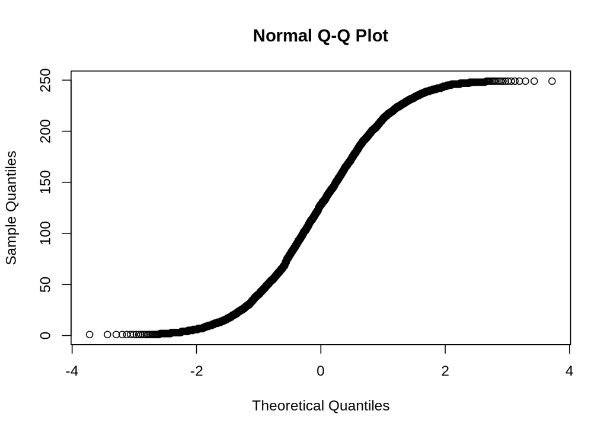

```r
qqnorm(Area_check)
```

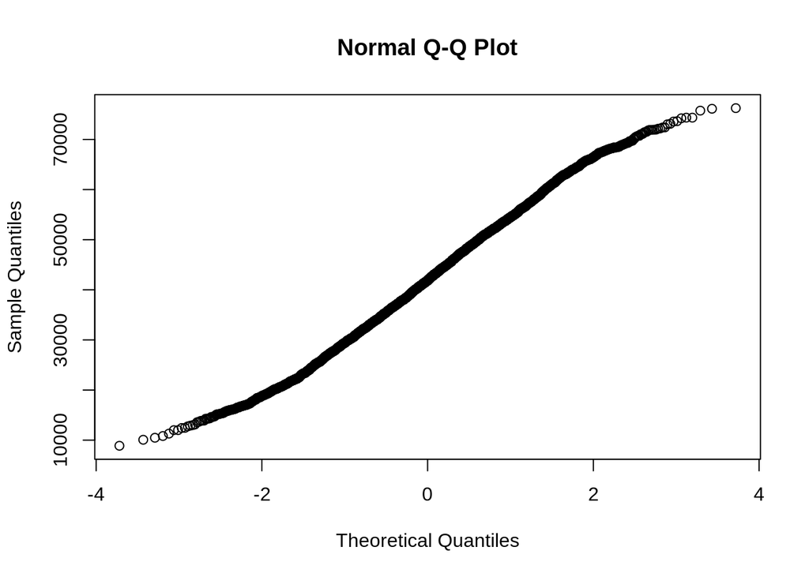

```r
qqnorm(Prices_check)
```

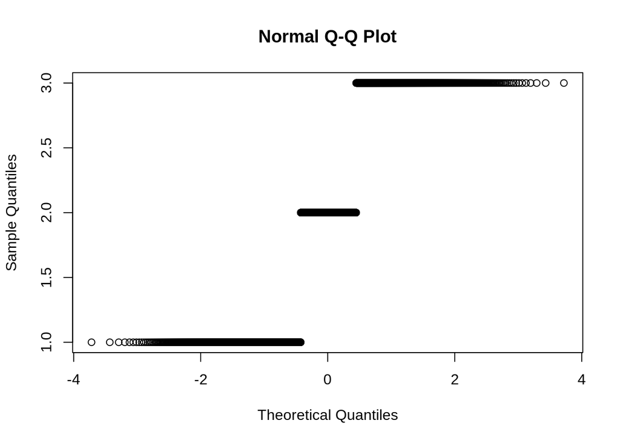

```r
qqnorm(City_check)
```

Plot shows that distribution is not normal

### 6.1.3 Normality Tester through Library BSDA

Center plot is the given data. Randomly generated normally distributed data is plotted on all sides of it. Red Means it is not Normally Distributed.

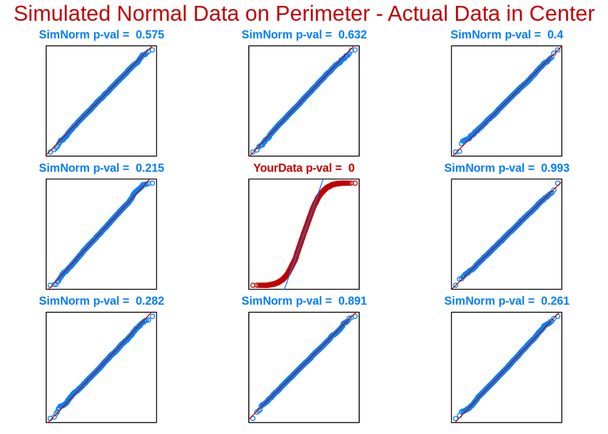

```r
library(BSDA)
ntester(Area_check)
```

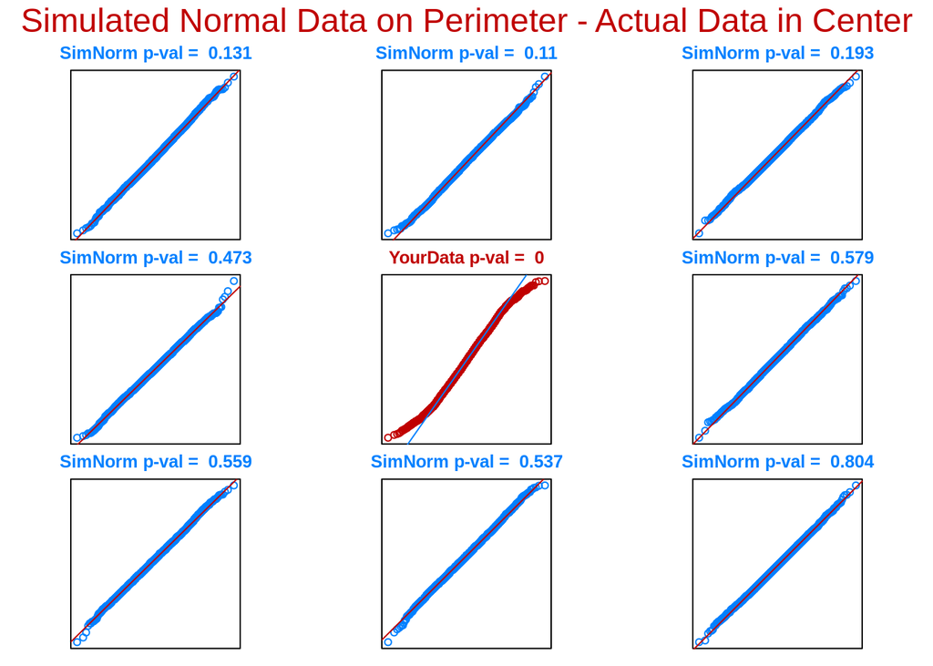

```r
ntester(Prices_check)
```

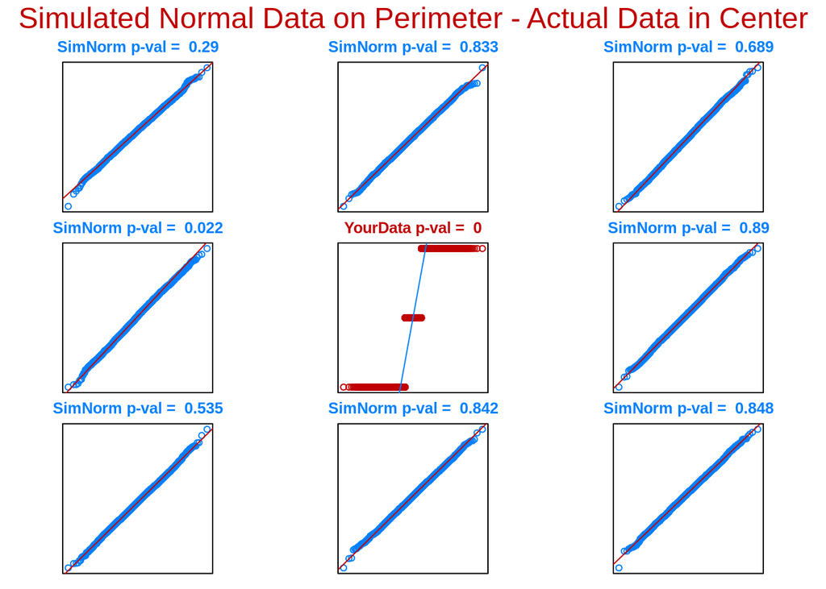

```r
ntester(City_check)
```

After doing all the Test, it can be concluded that the given Dataset is NOT NORMAL

# 7 Homegeneous Variance Test

To Test that the variance across the group is same or not

Homoscadasticity Or Heteroscadasticity is seen

## 7.1 Bartlett Test

Null Hypothesis : Variance across the group is same.

```r
bartlett.test(HousePrice[,1],HousePrice[,9])
```

```
##
##  Bartlett test of homogeneity of variances
##
## data:  HousePrice[, 1] and HousePrice[, 9]
## Bartlett's K-squared = 0.41935, df = 2, p-value = 0.8108
```

Area And City - Same Variance

```r
bartlett.test(HousePrice[,8],HousePrice[,3])
```

```
##
##  Bartlett test of homogeneity of variances
##
## data:  HousePrice[, 8] and HousePrice[, 3]
## Bartlett's K-squared = 1.3589e-05, df = 4, p-value = 1
```

FirePlace and Floor - Same Variance

```r
bartlett.test(HousePrice[,6],HousePrice[,12])
```

```
##
##  Bartlett test of homogeneity of variances
##
## data:  HousePrice[, 6] and HousePrice[, 12]
## Bartlett's K-squared = 0.00067991, df = 1, p-value = 0.9792
```

Black Marble and Fiber - Same Variance

```r
bartlett.test(HousePrice[,16]~HousePrice[,9])
```

```
##
##  Bartlett test of homogeneity of variances
##
## data:  HousePrice[, 16] by HousePrice[, 9]
## Bartlett's K-squared = 3.6669, df = 2, p-value = 0.1599
```

p-value is greater than 0.05(alpha level)

# 8 Anova Test

This is done to analyse the variance of the dataset.

City is taken as factor.

```r
attach(HousePrice)
city_factor<-as.factor(City)
aov_1 <- aov(Prices~city_factor)
summary(aov_1)
```

```
##                Df    Sum Sq   Mean Sq F value Pr(>F)
## city_factor 2e+00 3.990e+12 1.995e+12   14387 <2e-16 ***
## Residuals   5e+05 6.934e+13 1.387e+08
## ---
## Signif. codes:  0 '***' 0.001 '**' 0.01 '*' 0.05 '.' 0.1 ' ' 1
```

Summary Shows P-Values is close to 0 (<0.05) therefore there is a variation between city and prices

# 9 Differences between the Mean level of City

95% confidence level It shows the difference between two cities

```r
HSDTEST<-TukeyHSD(aov_1)
HSDTEST
```

```
##   Tukey multiple comparisons of means
##     95% family-wise confidence level
##
## Fit: aov(formula = Prices ~ city_factor)
##
## $city_factor
##         diff      lwr      upr p adj
## 2-1 3393.119 3297.494 3488.745     0
## 3-1 6921.754 6826.111 7017.396     0
## 3-2 3528.634 3433.076 3624.192     0
```

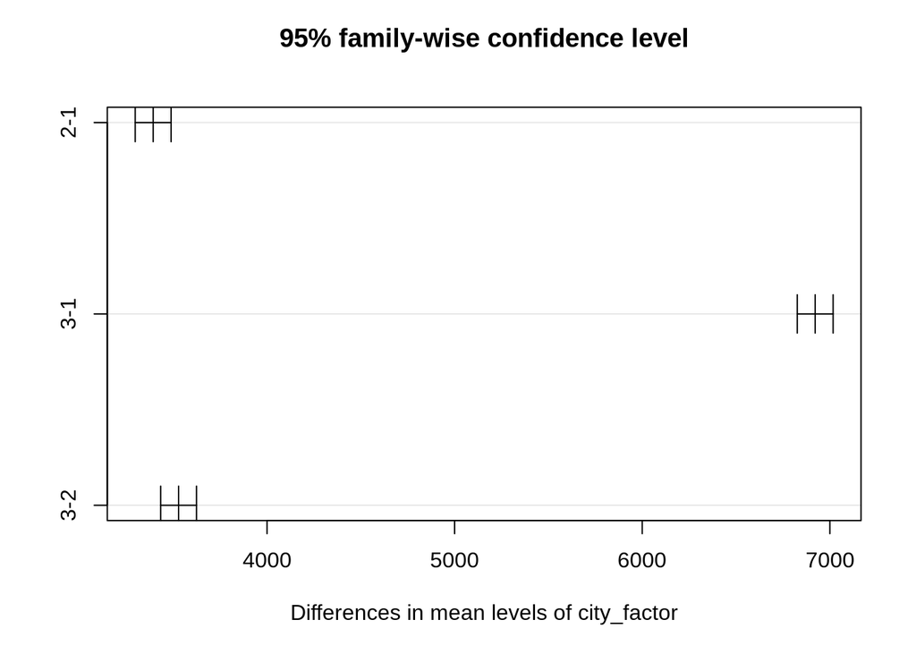

```r
plot(HSDTEST)
```

```r
model.tables(aov_1,"effects")
```

```
## Tables of effects
##
##  city_factor
##          1         2      3
##      -3442    -48.39   3480
## rep 166314 166902.00 166784
```

```r
model.tables(aov_1,"means")
```

```
## Tables of means
## Grand mean
##
## 42050.14
##
##  city_factor
##          1      2      3
##      38609  42002  45530
## rep 166314 166902 166784
```

We observe that there is a lot of difference between first city and third city.

# 10 Linear Regression

Area= B0 + Garage(B1) + FirePlace(B2) + Baths(B3) + White.Marble(B4) + Black.Marble(B5) + Floors(B6) + Solar(B7) + Electric(B8) + Fiber(B9) + Glass.Doors(B10) + Swiming.Pool(B12) + Garden(B13)

```r
attach(HousePrice)
model_area <- lm(Area~Garage+FirePlace+Baths+White.Marble+Black.Marble+Floors+Solar+Electric+Fiber+Glass.Doors+Swiming.Pool+Garden,data=HousePrice)
summary(model_area)
```

```
##
## Call:
## lm(formula = Area ~ Garage + FirePlace + Baths + White.Marble +
##     Black.Marble + Floors + Solar + Electric + Fiber + Glass.Doors +
##     Swiming.Pool + Garden, data = HousePrice)
##
## Residuals:
##      Min       1Q   Median       3Q      Max
## -124.633  -62.192    0.048   62.118  124.670
##
## Coefficients:
##               Estimate Std. Error t value Pr(>|t|)
## (Intercept)  124.96756    0.48157 259.501   <2e-16 ***
## Garage        -0.07939    0.12428  -0.639    0.523
## FirePlace      0.01889    0.07181   0.263    0.793
## Baths         -0.02102    0.07180  -0.293    0.770
## White.Marble   0.36289    0.24859   1.460    0.144
## Black.Marble  -0.04416    0.24865  -0.178    0.859
## Floors        -0.11141    0.20307  -0.549    0.583
## Solar          0.07682    0.20307   0.378    0.705
## Electric      -0.01862    0.20307  -0.092    0.927
## Fiber          0.01572    0.20307   0.077    0.938
## Glass.Doors   -0.17745    0.20307  -0.874    0.382
## Swiming.Pool   0.08849    0.20307   0.436    0.663
## Garden         0.20556    0.20307   1.012    0.311
## ---
## Signif. codes:  0 '***' 0.001 '**' 0.01 '*' 0.05 '.' 0.1 ' ' 1
##
## Residual standard error: 71.8 on 499987 degrees of freedom
## Multiple R-squared:  1.241e-05,  Adjusted R-squared:  -1.159e-05
## F-statistic: 0.5171 on 12 and 499987 DF,  p-value: 0.9054
```

Checking whether How area is affecting city.

City= B0 + Area(B1)

```r
model_city <- lm(City~Area,data=HousePrice)
summary(model_city)
```

```
##
## Call:
## lm(formula = City ~ Area, data = HousePrice)
##
## Residuals:
##      Min       1Q   Median       3Q      Max
## -1.00581 -0.99846 -0.00094  0.99659  1.00393
##
## Coefficients:
##               Estimate Std. Error t value Pr(>|t|)
## (Intercept)  2.006e+00  2.317e-03 865.856   <2e-16 ***
## Area        -3.928e-05  1.608e-05  -2.443   0.0146 *
## ---
## Signif. codes:  0 '***' 0.001 '**' 0.01 '*' 0.05 '.' 0.1 ' ' 1
##
## Residual standard error: 0.8162 on 499998 degrees of freedom
## Multiple R-squared:  1.194e-05,  Adjusted R-squared:  9.937e-06
## F-statistic: 5.969 on 1 and 499998 DF,  p-value: 0.01456
```

Checking whether How Price is affected by Area or by City

```r
model_Price_1 <- lm(Prices~Area,data=HousePrice)

summary(model_Price_1)
```

```
##
## Call:
## lm(formula = Prices ~ Area, data = HousePrice)
##
## Residuals:
##    Min     1Q Median     3Q    Max
## -31686  -8430   -223   8581  33033
##
## Coefficients:
##              Estimate Std. Error t value Pr(>|t|)
## (Intercept) 3.894e+04  3.399e+01  1145.4   <2e-16 ***
## Area        2.492e+01  2.359e-01   105.6   <2e-16 ***
## ---
## Signif. codes:  0 '***' 0.001 '**' 0.01 '*' 0.05 '.' 0.1 ' ' 1
##
## Residual standard error: 11980 on 499998 degrees of freedom
## Multiple R-squared:  0.02182,    Adjusted R-squared:  0.02182
## F-statistic: 1.115e+04 on 1 and 499998 DF,  p-value: < 2.2e-16
```

```r
model_Price_2 <- lm(Prices~City,data=HousePrice)
summary(model_Price_2)
```

```
##
## Call:
## lm(formula = Prices ~ City, data = HousePrice)
##
## Residuals:
##    Min     1Q Median     3Q    Max
## -31033  -8147   -397   8589  32589
##
## Coefficients:
##             Estimate Std. Error t value Pr(>|t|)
## (Intercept) 35125.07      44.09   796.6   <2e-16 ***
## City         3460.91      20.40   169.6   <2e-16 ***
## ---
## Signif. codes:  0 '***' 0.001 '**' 0.01 '*' 0.05 '.' 0.1 ' ' 1
##
## Residual standard error: 11780 on 499998 degrees of freedom
## Multiple R-squared:  0.05441,    Adjusted R-squared:  0.05441
## F-statistic: 2.877e+04 on 1 and 499998 DF,  p-value: < 2.2e-16
```

# 11 CONCLUSION :-

-Dataset is not normally distributed.

-TukeyHSD shows the difference beteen cities prices are significant.

-Prices varies with respect to City